## Identify co-expression gene modules by the App and Age phenotypes

Xulong Wang (xulong.wang@jax.org)

```r
rm(list = ls())
setwd("~/Dropbox/GitHub/Ad")
load("./data/brain_bc2014.rdt")
source("function.R")
```

##### Batch-corrected gene expression dataset from GLM was filtered to keep the most variable genes across conditions for downstream analysis. We applied ANOVA first to remove genes that were highly variable among replciates, followed by an explicit selection of highly variable genes among conditons.

```r
dt <- dt.bc
aov.pval <- NULL
for (i in 1:nrow(dt)) {
# if (i %% 1e3 == 0) cat(i, "\n")
  dat1 <- data.frame(y = as.matrix(dt)[i, ], age, group)
  aov <- aov(y ~ age * group, data = dat1)
  aov.pval <- c(aov.pval, min(summary(aov)[[1]][["Pr(>F)"]], na.rm = T))
}
dt.cond <- NULL
dt <- dt[aov.pval < 0.05, ]
for (idx in conditions) dt.cond <- cbind(dt.cond, rowMeans(dt[, uid == idx]))
colnames(dt.cond) <- conditions
dt.cond <- dt.cond[apply(dt.cond, 1, sd) > 0.1, ]
dt <- as.data.frame(dt.cond)
n.gene <- nrow(dt)
geneId <- rownames(dt)
str(dt)
```

```
## 'data.frame':    842 obs. of  8 variables:
##  $ 2m_WT : num  2.69 4.56 5.71 3.25 3.86 ...
##  $ 2m_APP: num  2.65 4.68 5.89 3.38 4.06 ...
##  $ 4m_WT : num  3.04 4.63 5.88 3.52 3.77 ...
##  $ 4m_APP: num  3.09 4.63 5.93 3.38 4 ...
##  $ 5m_WT : num  3.05 4.77 6.03 3.65 4.12 ...
##  $ 5m_APP: num  2.97 4.78 5.94 3.5 4.04 ...
##  $ 6m_WT : num  3.19 4.92 6.15 3.61 4.17 ...
##  $ 6m_APP: num  3.09 4.84 5.89 3.34 3.95 ...
```

##### A similarity measure, which describes the distances between network nodes, is the core for network construction. We constructed a topology overlap matrix (TOM) as the similarity measure based on the assumption that gene expression networks follow the scale free topology rule. The TOM took acount not only distance between two nodes, but also how many nodes they share. Code block below constructs the TOM.

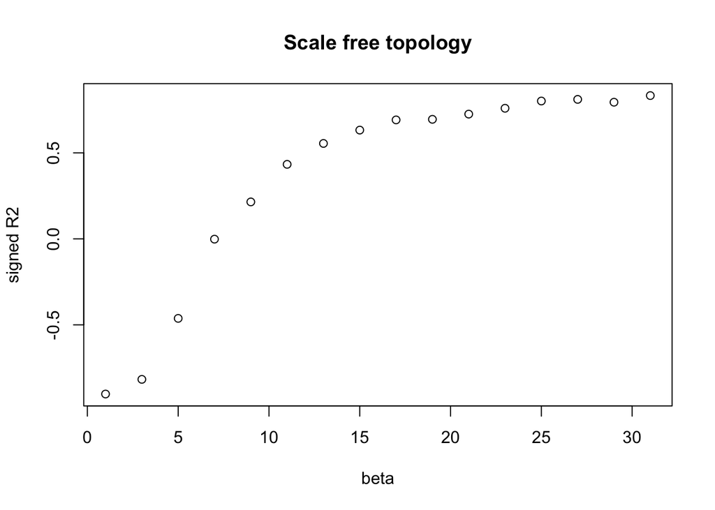

```r
sft <- NULL  # --- Scale free topology
similarity <- cor(t(dt), method = "pearson")
diag(similarity) <- 0
for (beta in seq(1, 31, 2)) {
  adjacency <- abs(similarity)^beta
  k1 <- rowSums(adjacency)
  discretized.k = cut(k1, 20)  # breaks:20
  dk = tapply(k1, discretized.k, mean)
  p.dk = tapply(k1, discretized.k, length) / length(k1)
  dk = dk[! is.na(dk)]
  p.dk = p.dk[! is.na(p.dk)]
  fit <- summary(lm(log10(p.dk) ~ log10(dk)))
  sr2 <- -sign(fit$coefficients["log10(dk)", "Estimate"]) * fit$r.squared
  sft <- rbind(sft, c(beta, sr2))
}
plot(sft, main = "Scale free topology", xlab = "beta", ylab = "signed R2")
```

```r
sft.beta <- 27
adjacency <- abs(similarity)^sft.beta
tom <- matrix(0, n.gene, n.gene)
rownames(tom) <- colnames(tom) <- geneId
k1 <- rowSums(adjacency)
for (i in 2:n.gene) {
# if (i %% 1e2 == 0) cat(i, "\n")
  for (j in 1:(i-1)) {
    kij <- min(k1[c(i, j)])
    lij <- sum(adjacency[i, ] * adjacency[j, ])
    wij <- (lij + adjacency[i, j]) / (kij + 1 - adjacency[i, j])
    tom[i, j] <- wij
  }
}
diag(tom) <- 1
tom[upper.tri(tom)] <- t(tom)[upper.tri(tom)]
diss.tom <- 1 - tom
```

##### To detect co-expression gene modules, hierarchical clustering was applied on the TOM. Modules were identified by cutting the hierarchical clustering dendrogram into branches.

```r
dendro <- hclust(as.dist(diss.tom), method = "average")
branch <- cutreeDynamic(dendro = dendro, distM = diss.tom, minClusterSize = 30)
```

```
##  ..cutHeight not given, setting it to 0.996  ===>  99% of the (truncated) height range in dendro.
##  ..done.
```

```r
names(branch) <- geneId
table(branch)
```

```
## branch
##   0   1   2   3   4   5   6   7   8
##  80 175 167  92  81  68  63  61  55
```

##### Genes in each modules were retrieved.

```r
geneId.network <- list()
for (idx in 1:8) geneId.network[[idx]] <- names(branch[branch == idx])
geneId.network[[6]]
```

```
##  [1] "2900079G21Rik" "Abhd14b"       "Acat2"         "Aldh1a2"
##  [5] "App"           "Arpp21"        "Arrdc1"        "BC051226"
##  [9] "Cd97"          "Chordc1"       "Creld2"        "Cryab"
## [13] "Cys1"          "Dhcr24"        "Dnajb11"       "Dnajc3"
## [17] "E130307A14Rik" "Fdft1"         "Fdps"          "Gm6741"
## [21] "Gm7120"        "Gstk1"         "Hsp90b1"       "Hspa1b"
## [25] "Hspa5"         "Hspb1"         "Insig1"        "Iqgap2"
## [29] "Klhl29"        "Lamr1-ps1"     "Lime1"         "Magt1"
## [33] "Manf"          "Mapk12"        "Mas1"          "Mical1"
## [37] "Mllt3"         "Nsdhl"         "Pdia3"         "Pdia4"
## [41] "Pdia6"         "Prnp"          "Psen1"         "Pstpip2"
## [45] "Rab34"         "Rps6ka5"       "Sars2"         "Sc4mol"
## [49] "Sdf2l1"        "Sh3rf3"        "Simc1"         "Slc6a13"
## [53] "Spice1"        "Srebf1"        "Stard4"        "Stx2"
## [57] "Taf6l"         "Tnni1"         "Tox"           "Wdr6"
## [61] "Xbp1"          "Zdhhc14"       "Zfp316"
```

##### Expression patterns of genes in each module can be represented by a psedo-gene, which was computed as the first principal component of the module genes’s expression profiles.

```r
eigene <- NULL
branchId <- names(table(branch))[-1]
for (idx in branchId) {
  dt1 <- dt[branch == idx, ]
  dt1 <- t(apply(dt1, 1, scale))
  svd1 <- svd(dt1)
  eigene <- rbind(eigene, svd1$v[, 1])
}
dimnames(eigene) <- list(branchId, conditions)
eigene
```

```
##        2m_WT     2m_APP      4m_WT      4m_APP       5m_WT      5m_APP
## 1  0.6632218 0.35624566  0.2033820 -0.21006654 -0.09802138 -0.11791111
## 2  0.1916304 0.30917783  0.2897103  0.39027857 -0.42919254 -0.24998017
## 3 -0.5438939 0.19907435 -0.1677622  0.68829209 -0.16697055 -0.17243843
## 4  0.6248093 0.02458426  0.3704853 -0.53129040  0.06120542  0.04275681
## 5  0.4281511 0.22505044  0.4689793  0.06068565 -0.31676934 -0.16827792
## 6 -0.6987521 0.24177031 -0.1956630  0.47194665 -0.08425936  0.05944665
## 7 -0.2650222 0.34443554  0.1408547  0.57889243 -0.34255449 -0.22130511
## 8  0.5661642 0.36452472  0.1345917  0.15107376 -0.29805442 -0.16890974
##        6m_WT      6m_APP
## 1 -0.3403853 -0.45646509
## 2 -0.6106230  0.10899856
## 3 -0.1322137  0.29591227
## 4 -0.2316699 -0.36088079
## 5 -0.6406959 -0.05712343
## 6 -0.1805502  0.38606101
## 7 -0.4797057  0.24440495
## 8 -0.6065159 -0.14287440
```

##### What the psedo-genes look like?

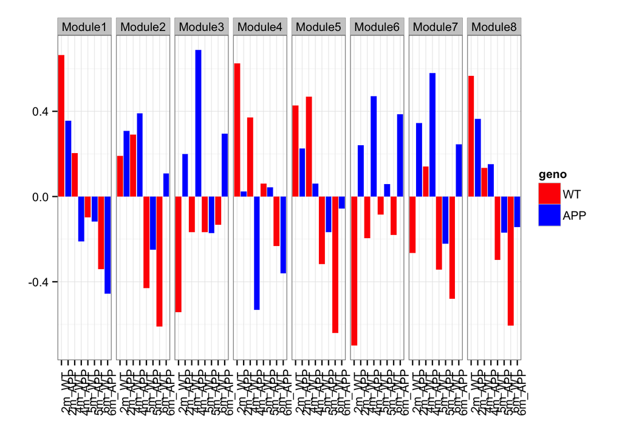

```r
module <- paste("Module", branchId, sep = "")
group <- factor(conditions, levels = conditions)
gdt <- data.frame(value = c(eigene), module = rep(module, 8), group = rep(group, each = 8))
gdt$geno <- factor(gsub("^.*(WT|APP).*", "\\1", gdt$group), levels = c("WT", "APP"))
ggplot(gdt, aes(x = group, y = value, fill = geno)) +
  geom_bar(stat = "identity") + facet_grid(. ~ module) +
  scale_fill_manual(values = c("red", "blue")) +
  theme_bw() + xlab("") + ylab("") +
  theme(axis.text.x = element_text(angle = 90))
```

```r
x.dt = as.matrix(dt[branch == 6, ])
x.dt <- t(apply(x.dt, 1, scale))
gdt <- data.frame(value = c(x.dt), gene = rep(rownames(x.dt), 8), group = rep(group, each = nrow(x.dt)))
gdt %>% ggvis(~group, ~value, stroke = ~gene) %>% layer_lines() %>% hide_legend("stroke") %>%
  add_tooltip(function (x) paste("Gene: ", x$gene), "hover")
```

[output not shown]

##### GO and KEGG enrichment

```r
geneId <- geneId.network[[6]]
gk.mod6 <- myGK(geneId)
head(gk.mod6$BP[, c("Term", "Pvalue")])
```

```
##                                       Term       Pvalue
## 1         cholesterol biosynthetic process 4.641597e-10
## 2              sterol biosynthetic process 1.015274e-09
## 3 response to endoplasmic reticulum stress 4.300976e-09
## 4            cholesterol metabolic process 7.017771e-09
## 5                 sterol metabolic process 1.039242e-08
## 6                       response to stress 1.861415e-08
```

```r
head(gk.mod6$MF[, c("Term", "Pvalue")])
```

```
##                                                            Term
## 1                                     misfolded protein binding
## 2                          protein disulfide isomerase activity
## 3 intramolecular oxidoreductase activity, transposing S-S bonds
## 4                                      unfolded protein binding
## 5                                                       binding
## 6                             farnesyltranstransferase activity
##         Pvalue
## 1 1.932505e-06
## 2 1.294934e-05
## 3 1.294934e-05
## 4 1.749237e-05
## 5 2.819179e-05
## 6 1.362861e-04
```

```r
head(gk.mod6$CC[, c("Term", "Pvalue")])
```

```
##                           Term       Pvalue
## 1 smooth endoplasmic reticulum 5.067945e-15
## 2        endoplasmic reticulum 2.937774e-10
## 3             cytoplasmic part 2.653709e-09
## 4      intracellular organelle 8.876390e-08
## 5  endoplasmic reticulum lumen 1.274907e-07
## 6                    organelle 1.380182e-07
```

```r
head(gk.mod6$KEGG[, c("Term", "Pvalue")])
```

```
##                                          Term       Pvalue
## 1 Protein processing in endoplasmic reticulum 1.170606e-09
## 2                        Steroid biosynthesis 5.875966e-05
## 3             Terpenoid backbone biosynthesis 1.627351e-03
## 4         Antigen processing and presentation 4.593338e-03
```